# StockResearch

Gabriel Foix

2021-03-03

Buy Quality at the a good momentum and get rid of the fishy stocks on time. That's all.

### Define candidates

Download all info needed applying the following filters:

### Factor 1: Quality

1. Healthy debts: A company shoud generate cash in order to repay its debt. The **Free Cash Flow to Debt** ratio is a good indicator of how quick a company pays back its debt. The lower this ratio the better.

FCF2D = $\frac{Debt}{Free Cash Flow}$

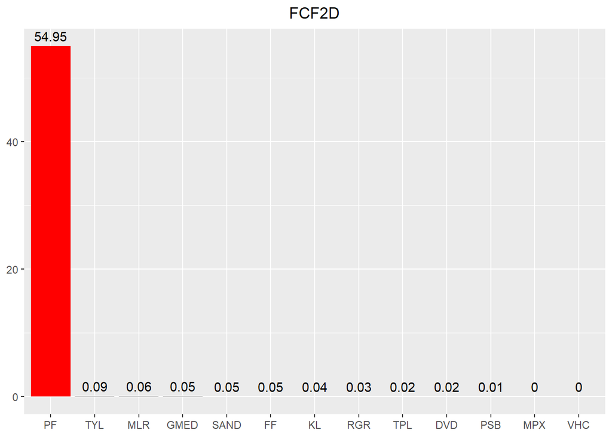

2. Profitability: ROA

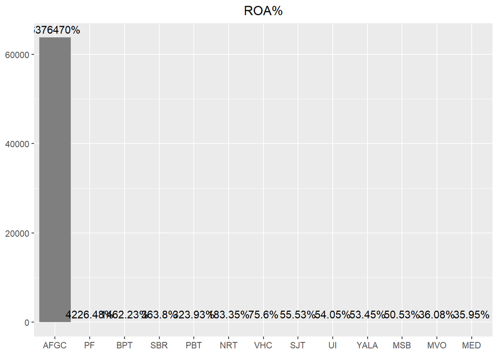

3. High Margin: We look for companies that generate free cash flow compare to its price. The **Free Cash Flow to Entreprise Value** ratio tells us how many years of cash flow would be needed to the return the 100% of the investment. Again, the lower, the better. Values bellow 1 would mean "free lunch".

FCF2EV = $\frac{EV}{Free Cash Flow}$

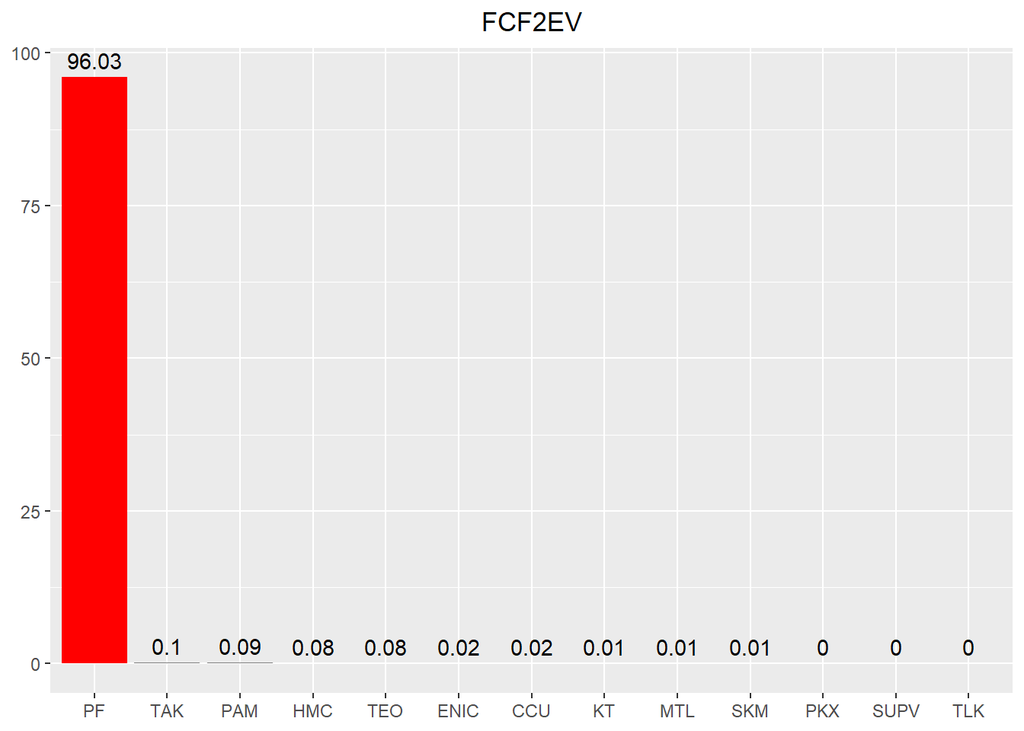

#### Download Historical Data

Download only stocks not filtered previously

### Value touch

Filter out stocks with PER > 40

Report Candidates

Filter Summary

| Filter | NStocks |
| --- | --- |
| Initial | 3221 |
| ROA | 1511 |
| FCF | 1247 |
| Hist1Y | 1233 |
| PER | 692 |

### Factor 2: Momentum

Don't hold onto a stock simply because it is high quality. So called quality stocks have cycles too. Stan Weinstein (page 177)

Generic Intermediate-Term Momentum Based on Gray-Vogel (page 80)

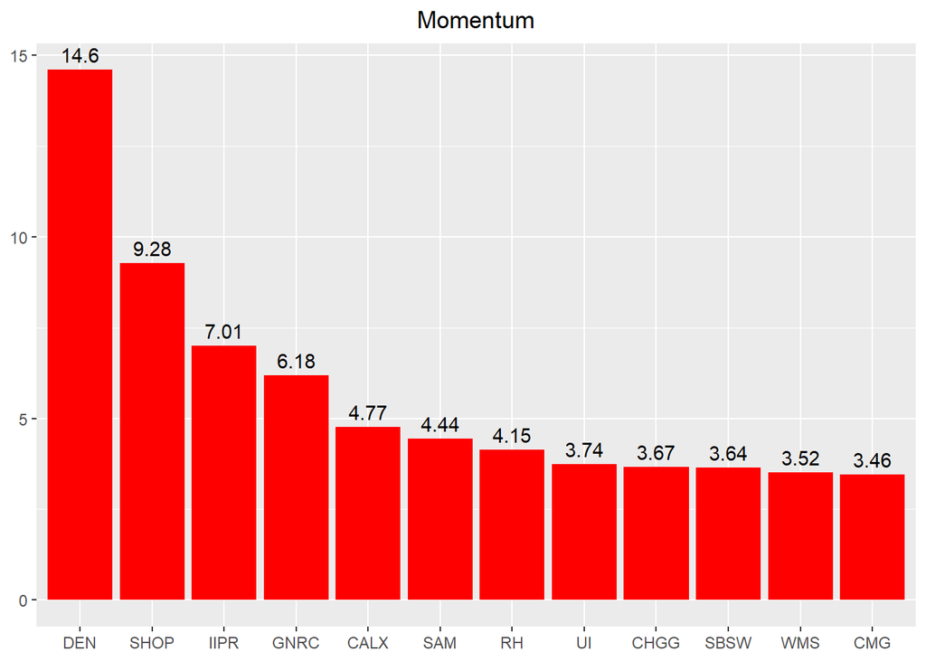

### Factor 3: Timing Signal

Sell Signal - Pr < 1% SMA 30 weeks and slope negative (< -0.2)  
Buy Signal - 109% * SMA30 < Pr > SMA 30 and slope positive (> 0.2)  
Hold Signal - Neither Buy nor Sell

#### Calc Market Cap

Using free float shares

### Summary

Summary

| Ticker | Signal | Quality | Momentum | Final_rank | PER | MCap |
| --- | --- | --- | --- | --- | --- | --- |
| SID | HOLD | 1444.0 | 1172 | 1424.0 | 8.7011173 | 4002163961 |
| MOH | BUY | 1414.0 | 1185 | 1418.0 | 18.8860193 | 11560194308 |
| VHC | HOLD | 1470.0 | 1127 | 1417.0 | 1.6629101 | 417087309 |
| DHT | HOLD | 1446.0 | 1148 | 1416.0 | 3.6521740 | 835733454 |
| YETI | HOLD | 1375.0 | 1218 | 1415.0 | 39.1751392 | 5674920097 |
| DECK | HOLD | 1371.0 | 1214 | 1411.0 | 24.9316453 | 8968009359 |
| HZO | HOLD | 1423.0 | 1159 | 1408.5 | 11.8998751 | 967411350 |
| WSM | HOLD | 1392.0 | 1190 | 1408.5 | 19.4398002 | 10051247283 |
| KL | SELL | 1428.0 | 1147 | 1403.0 | 11.3534865 | 8821478181 |
| MED | HOLD | 1358.0 | 1201 | 1397.5 | 29.3110597 | 2592348203 |
| IDT | HOLD | 1351.0 | 1199 | 1393.5 | 15.3327723 | 176805218 |
| BKE | HOLD | 1387.0 | 1160 | 1390.5 | 16.6286221 | 1073443660 |
| AU | SELL | 1403.0 | 1143 | 1389.0 | 8.8839874 | 8321225804 |
| APAM | BUY | 1440.0 | 1095 | 1385.0 | 14.0764708 | 2694770831 |
| GFI | SELL | 1376.5 | 1140 | 1381.0 | 10.4268295 | 7366634678 |
| ZTO | HOLD | 1335.0 | 1161 | 1376.0 | 38.8392849 | 14874200675 |
| ATKR | HOLD | 1268.5 | 1210 | 1375.0 | 16.7424977 | 3197098993 |
| RIO | HOLD | 1330.5 | 1135 | 1372.0 | 15.1483829 | 129048076710 |
| TGT | BUY | 1267.0 | 1196 | 1370.5 | 23.0282532 | 86674060691 |
| DKS | HOLD | 1301.0 | 1154 | 1365.0 | 16.9873303 | 4579393420 |
| LPX | HOLD | 1434.5 | 1019 | 1364.0 | 10.5852016 | 4986711333 |
| GPI | HOLD | 1279.0 | 1173 | 1363.0 | 9.8027075 | 2344867509 |
| MTH | SELL | 1385.0 | 1063 | 1361.0 | 7.5581818 | 3071321941 |
| VSTO | HOLD | 1346.0 | 1089 | 1357.0 | 31.5762542 | 1606139744 |
| TPX | HOLD | 1207.0 | 1202 | 1352.0 | 21.9695115 | 6843464719 |
| ECOM | HOLD | 1225.5 | 1178 | 1350.0 | 36.5396833 | 589431393 |
| GNE | SELL | 1406.0 | 991 | 1345.0 | 15.7028116 | 159956344 |
| EBS | SELL | 1339.5 | 1047 | 1340.0 | 16.7072316 | 4511631507 |
| HVT | HOLD | 1227.0 | 1155 | 1338.0 | 11.6858971 | 540775800 |
| FCN | HOLD | 1212.0 | 1167 | 1336.5 | 21.1534396 | 3906763840 |

[output cut: 662 more lines]

Save output in template